# STAT 8111 LECTURE NOTE 3

Jingxiang Li

09/08/2014

## Review

$\theta \in \Theta$, $d \in D$, $X:{P_{\theta}, \theta \in \Theta}$, $\delta: X \rightarrow D$, $L(\theta, d)$, $R(\theta, \delta) = E(L(\theta, \delta(X)))$

## Randomization

For $X = x$, Let $m_{x}$ be a probability measure on $D$, Then one decision is picked by selecting $d \in D$ using $m_{x}$.

$m:~X \rightarrow$ Space of probability measures on $D$

This is called *Behaviour Decision Rule*, which means

1. You have a class of probability measure function $m$
2. Observe $X = x$
3. Get a specific probability measure $m_{x}()$ on $D$
4. Randomly pick $d \in D$ based on $m_{x}(d)$

Let $Y_{x}$ denote the Random Decision you picked given the $X = x$,$E(L(\theta, Y_{x})) = \int_{D}{L(\theta,d)dm_{x}(d)}$ Which equals to expected Loss given the $X = x$ observed, and $\theta$ is the truth of nature and m_{x} is used.

$R(\theta, m) = \int_{X}\int_{D}{L(\theta, d)dm_{x}(d)dP_{\theta}^{x}}$

Thus in this way, the risk function is determined by $\theta$ and the probability measure function $m$.

There is a Second type of Randomization. Randomly pick two decision functions $\delta_{s}$, say $\delta_{1}$ and $\delta_{2}$, it’s called a *Randomized Decision rule*. But kind of equivalent to *Behaviour Decision Rule*.

Def. $\bar{D}=$ Class of all non-Randomized Decision rules

Def. $\bar{\bar{D}}=$ Class of all of Decision rules

Def. $D$ is convex, if $\forall d_{1}, d_{2} \in D$

$\alpha d_{1}+(1-\alpha)d_{2} \in D, \forall \alpha, 0 \leq \alpha\leq 1$

Def. $\phi$ be defined in D is convex (or strictly convex) if

$\phi(\alpha d_{1}+(1-\alpha)d_{2}) \leq_{(<)} \alpha\phi(d_{1}) + (1 - \alpha)\phi(d_{2})$

$\phi(E(X)) \leq E(\phi(X))$, $(E(X))^{2} \leq E(X^{2})$,

Q: Proof $\bar{D}$ is essentially complete on $\bar{\bar{D}}$.

Suppose $D$ is convex and $L(\theta, \cdot)$ is convex for each $\theta$. Suppose m is a behavior decision measure and $\delta$ is defined by $\delta_{x} = \int_{D}d\cdot dm_{x}(d)$ proof that $R(\theta, \delta) \leq R(\theta, m) \forall \theta \in \Theta$

**Proof:** $\begin{aligned} R(\theta, m) & = \int_{X}\int_{D}{L(\theta, d)dm_{x}(d)dP_{\theta}(x)}\\ & \geq \int_{X}L(\theta, \delta_{x})dP_{\theta}(x)\\ & = R(\theta, \delta)~\Box \end{aligned}$

Def: $C \subseteq \bar{\bar{D}}$ is *(essentially) complete* if given any $m \in \bar{\bar{D}}$, $\exists m' \in C$ such that $m'$ is (at least as good as) better than $m$.

Def: $m$ is *admissable* if there is no such $m' \in \bar{\bar{D}}$ which is better than $m$

## ———————–

$D \subseteq \mathbb{R}$, $D$ is convex, $X:~{P_{\theta}, \theta \in \Theta}$, $L(\theta, \cdot)$ is strictly convex for each $\theta$.

**Lemma:** Let $\delta_{0}$ and $\delta_{1}$ be two decision functions, such that $R(\theta, \delta_{0}) = R(\theta, \delta_{1}), \forall \theta \in \Theta$ if for some $\theta$, $P_{\theta}(\delta_{0}(x) = \delta_{1}(x)) < 1$, then $\delta_{0}$ (and hence $\delta_{1}$) is *inadmissible*.

**Proof:** Let $\delta^{*}(x) = \frac{\delta_{0}(x) + \delta_{1}(x)}{2}$, if $\delta_{0}(x) \neq \delta_{1}(x)$ for some $x$, then due to the convexity of L, we have $L(\theta, \delta^{*}(x)) < \frac{1}{2}L(\theta, \delta_{0}(x)) + \frac{1}{2}L(\theta, \delta_{1}(x))$

Let $\theta^{*}$ make $P_{\theta}(\delta_{0}(x) = \delta_{1}(x)) < 1$ true, then $EL(\theta^{*}, \delta^{*}(x)) < \frac{1}{2}EL(\theta^{*}, \delta_{0}(x)) + \frac{1}{2}EL(\theta^{*}, \delta_{1}(x))$ $R(\theta^{*}, \delta^{*}) < \frac{1}{2}R(\theta^{*}, \delta_{0}) + \frac{1}{2}R(\theta^{*}, \delta_{1})$ and thus $\delta^{*}$ beats $\delta_{0}$ and $\delta{1}$

Def. $\delta \in \bar{D}$ is unbiased for estimating some $\gamma(\theta)$ if $E(\delta(X)) = \gamma(\theta), \forall \theta \in \Theta$

**Corollary** If $L(\theta, \cdot)$ is strictly convex, and $\delta$ is the best unbiased estimator, then $\delta$ is unique.

## —————————

Jensen’s Inequality for Conditional Expectation

$I$ is an interval in $\mathbb{R}$, $\phi$ is convex in $\mathbb{R}$, $H = \{h,$ a line of support of $\phi$ at a real point in $I\}$

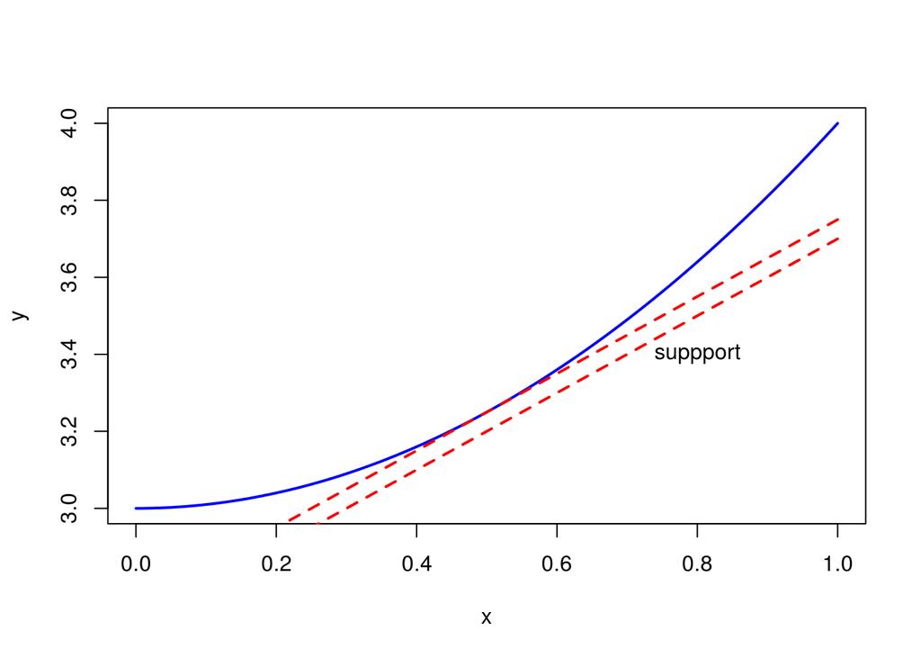

For $x \in I$, $\phi(x) = \sup_{h \in H}h(x)$